# rk1

## Рубежный контроль №1 (весна 2025 года)

## Тема: Методы обработки данных

Необходимо подготовить отчет по рубежному контролю и разместить его в Вашем репозитории. Вы можете использовать титульный лист, или в начале ноутбука в текстовой ячейке указать Ваши Ф.И.О. и группу.

**Тема:** Методы обработки данных.

### Варианты заданий

| Номер варианта | Номер задачи №1 | Номер задачи №2 |
| --- | --- | --- |
| 1 | 1 | 21 |
| 2 | 2 | 22 |
| ... | ... | ... |
| 22 | 7 | 33 |

**Выбор варианта:**

- Для групп **ИУ5-21М, ИУ5-22М, ИУ5-23М, ИУ5-24М**: номер в списке группы.
- Для групп **ИУ5И-21М, ИУ5И-22М, ИУ5И-23М, ИУ5И-24М**: 15 + номер в списке группы.
- Для группы **ИУ5-25МВ**: 20 + номер в списке группы.

**Дополнительные требования по группам:**

- **ИУ5-21М, ИУ5И-21М**: для пары произвольных колонок данных построить график "Диаграмма рассеяния".
- **ИУ5-22М, ИУ5И-22М**: для произвольной колонки данных построить гистограмму.
- **ИУ5-23М, ИУ5И-23М**: для произвольной колонки данных построить график "Ящик с усами (boxplot)".
- **ИУ5-24М, ИУ5И-24М**: для произвольной колонки данных построить график "Скрипичная диаграмма (violin plot)".
- **ИУ5-25МВ**: для произвольной колонки данных построить парные диаграммы (pairplot).

**Условия выбора данных:**

- Набор данных выбирается произвольно.
- Должен отличаться от лекционного примера.
- Должен соответствовать условиям задачи (например, содержать пропуски, если задача на их устранение).

**Студент:** Папин Алексей Владимирович

**Группа:** ИУ5Ц-21М

### Описание набора данных

В работе используется набор данных **Global E-Commerce Sales Dataset (2021–2024)**. Это синтетический датасет, имитирующий транзакции в сфере электронной коммерции. Он содержит 10 000 записей и 26 признаков, включая:

- **Идентификаторы:** ID заказа и клиента.
- **Временные признаки:** Дата, год, месяц, квартал и сезон.
- **Географические данные:** Регион и страна.
- **Категориальные данные:** Сегмент клиента, категория и подкатегория товара, метод доставки, способ оплаты и статус заказа.
- **Количественные показатели:** Цена за единицу, количество, скидка, выручка (`Revenue`), себестоимость (`Cost`), прибыль (`Profit`) и маржинальность.

Данный набор данных позволяет проводить глубокий анализ эффективности продаж, исследовать зависимости между затратами и прибылью, а также практиковать методы машинного обучения.

### Задачи:

1. **Задача №1:** Построить график "Диаграмма рассеяния (scatter plot)" для пары произвольных колонок данных
2. **Задача №2:** Кодирование категориального признака методом Target (Mean) Encoding
3. **Задача №22:** Масштабирование числового признака по максимальному значению (MaxAbs Scaling)

## Импорт библиотек и загрузка данных

```
Размер набора данных: (10000, 26)

Первые 5 строк:
```

|  | Order_ID | Order_Date | Year | Month | Quarter | Season | Customer_ID | Customer_Gender | Customer_Segment | Region | ... | Discount | Revenue | Cost | Profit | Profit_Margin_% | Shipping_Cost | Shipping_Method | Shipping_Days | Payment_Method | Order_Status |
| --- | --- | --- | --- | --- | --- | --- | --- | --- | --- | --- | --- | --- | --- | --- | --- | --- | --- | --- | --- | --- | --- |
| 0 | ORD-000001 | 2023-01-18 | 2023 | 1 | Q1 | Winter | CUST-02791 | Male | New | North America | ... | 0.00 | 3642.80 | 2444.11 | 1198.69 | 32.91 | 2.25 | Economy | 4 | Google Pay | Delivered |
| 1 | ORD-000002 | 2023-11-13 | 2023 | 11 | Q4 | Fall | CUST-02763 | Female | Regular | North America | ... | 0.25 | 33.88 | 28.32 | 5.56 | 16.41 | 4.72 | Economy | 5 | Credit Card | Delivered |
| 2 | ORD-000003 | 2022-04-28 | 2022 | 4 | Q2 | Spring | CUST-05729 | Male | Regular | North America | ... | 0.00 | 241.30 | 161.41 | 79.89 | 33.11 | 13.28 | Standard | 8 | Credit Card | Processing |
| 3 | ORD-000004 | 2021-10-22 | 2021 | 10 | Q4 | Fall | CUST-06490 | Female | Regular | Asia | ... | 0.00 | 654.50 | 369.16 | 285.34 | 43.60 | 31.11 | Express | 16 | Google Pay | Processing |
| 4 | ORD-000005 | 2023-08-06 | 2023 | 8 | Q3 | Summer | CUST-07594 | Female | Premium | Europe | ... | 0.20 | 178.82 | 118.69 | 60.13 | 33.63 | 8.44 | Standard | 5 | Debit Card | Delivered |

5 rows × 26 columns

```
Информация о данных:
<class 'pandas.core.frame.DataFrame'>
RangeIndex: 10000 entries, 0 to 9999
Data columns (total 26 columns):
 #   Column            Non-Null Count  Dtype
---  ------            --------------  -----
 0   Order_ID          10000 non-null  object
 1   Order_Date        10000 non-null  object
 2   Year              10000 non-null  int64
 3   Month             10000 non-null  int64
 4   Quarter           10000 non-null  object
 5   Season            10000 non-null  object
 6   Customer_ID       10000 non-null  object
 7   Customer_Gender   10000 non-null  object
 8   Customer_Segment  10000 non-null  object
```

[output cut: 21 more lines]

|  | Year | Month | Unit_Price | Quantity | Discount | Revenue | Cost | Profit | Profit_Margin_% | Shipping_Cost | Shipping_Days |
| --- | --- | --- | --- | --- | --- | --- | --- | --- | --- | --- | --- |
| count | 10000.000000 | 10000.000000 | 10000.000000 | 10000.000000 | 10000.00000 | 10000.000000 | 10000.000000 | 10000.000000 | 10000.000000 | 10000.000000 | 10000.000000 |
| mean | 2022.756300 | 6.604300 | 236.307452 | 2.731300 | 0.17675 | 528.438770 | 384.674939 | 143.763831 | 23.648594 | 32.299889 | 11.436100 |
| std | 0.878628 | 3.406799 | 380.901351 | 2.038508 | 0.16167 | 1154.811538 | 828.069100 | 420.487992 | 21.496639 | 28.424003 | 5.347633 |
| min | 2021.000000 | 1.000000 | 10.010000 | 1.000000 | 0.00000 | 5.330000 | 4.850000 | -1572.900000 | -50.000000 | 2.000000 | 3.000000 |
| 25% | 2022.000000 | 4.000000 | 42.767500 | 1.000000 | 0.00000 | 67.227500 | 50.017500 | 9.007500 | 13.497500 | 8.260000 | 7.000000 |
| 50% | 2023.000000 | 7.000000 | 92.495000 | 2.000000 | 0.15000 | 164.600000 | 121.395000 | 34.745000 | 28.330000 | 20.300000 | 10.000000 |
| 75% | 2023.000000 | 10.000000 | 221.822500 | 4.000000 | 0.30000 | 469.952500 | 339.020000 | 118.475000 | 39.082500 | 50.362500 | 15.000000 |
| max | 2024.000000 | 12.000000 | 2497.760000 | 10.000000 | 0.50000 | 19966.500000 | 15729.670000 | 9144.150000 | 54.990000 | 99.990000 | 25.000000 |

### Анализ описательной статистики

На основе полученных данных можно сделать следующие выводы:

1. **Revenue (Выручка):**
   - **Асимметрия:** Среднее значение (**528.44**) значительно превышает медиану (**164.60**), что указывает на правостороннее смещение распределения.
   - **Выбросы:** Максимальное значение (**19 966.50**) аномально велико по сравнению с 75-м процентилем (**469.95**). Это свидетельствует о наличии экстремальных заказов.
2. **Profit (Прибыль):**
   - **Убытки:** Минимальное значение отрицательное (**-1572.90**), что говорит о наличии заказов с убытком.
   - **Выбросы:** Максимальное значение (**9144.15**) многократно превышает 75-й процентиль (**118.48**), что также указывает на наличие выбросов.
   - **Разброс:** Высокое стандартное отклонение (**420.49**) относительно медианы (**34.75**) подтверждает неоднородность данных.

**Вывод:** Наличие экстремальных значений в признаках `Revenue` и `Profit` требует проведения предобработки данных (удаления выбросов) для корректного построения графиков.

## Предобработка данных: удаление выбросов

Проанализируем признаки `Revenue` (выручка) и `Profit` (прибыль) на наличие выбросов с помощью метода межквартильного размаха (IQR).

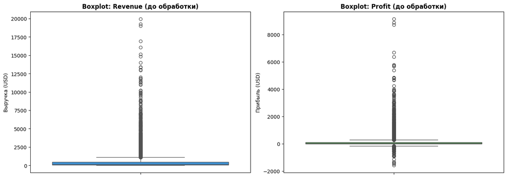

```
Обнаружение выбросов (метод IQR):
Revenue: выбросов = 1177 из 10000 (11.8%)
  Границы: [-536.86, 1074.04]
Profit: выбросов = 898 из 8823 (10.2%)
  Границы: [-100.85, 188.63]
```

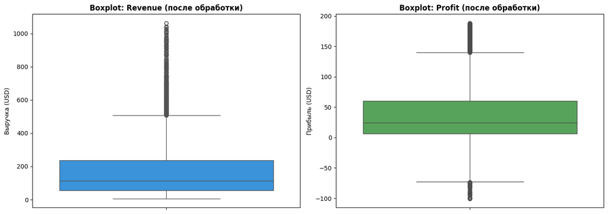

```
Размер данных до обработки: (10000, 26)
Размер данных после обработки: (7925, 26)
Удалено строк: 2075

Описательная статистика после удаления выбросов:
```

|  | Revenue | Profit |
| --- | --- | --- |
| count | 7925.000000 | 7925.000000 |
| mean | 174.636753 | 38.089692 |
| std | 174.047738 | 48.895000 |
| min | 5.330000 | -100.730000 |
| 25% | 54.510000 | 6.770000 |
| 50% | 112.950000 | 24.190000 |
| 75% | 236.050000 | 60.190000 |
| max | 1063.290000 | 188.620000 |

**Результат:** Выбросы удалены из признаков `Revenue` и `Profit` методом IQR. Дальнейший анализ проводится на очищенном наборе данных `df_clean`.

## Задача №1. Диаграмма рассеяния (Scatter Plot)

Построим scatter plot для пары признаков `Revenue` (выручка) и `Profit` (прибыль), чтобы проанализировать их корреляцию на очищенных данных.

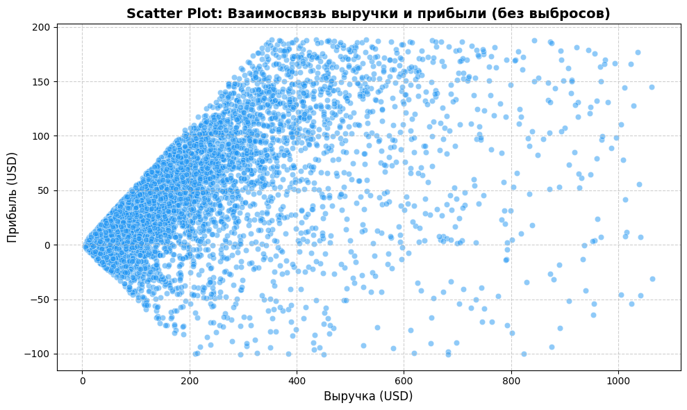

### Анализ диаграммы рассеяния

**Вывод по задаче №1:** Диаграмма рассеяния подтверждает гипотезу о прямой зависимости прибыли от выручки и демонстрирует отсутствие аномальных отклонений в очищенном наборе данных.

## Задача №2. Target (Mean) Encoding

Проведём кодирование категориального признака `Shipping_Method` (метод доставки) методом Target Encoding. Целевая переменная — `Shipping_Days` (дни доставки).

```
Уникальные значения 'Shipping_Method':
Shipping_Method
Economy      2007
Overnight    1990
Express      1982
Standard     1946
Name: count, dtype: int64

Количество уникальных значений: 4
```

```
Среднее время доставки по методам (Target Encoding):
Shipping_Method
Economy      11.474340
Express      11.226034
Overnight    11.519095
Standard     11.393114
Name: Shipping_Days, dtype: float64
```

```
Словарь кодирования:
{'Economy': 11.47433981066268, 'Express': 11.226034308779012, 'Overnight': 11.519095477386935, 'Standard': 11.39311408016444}

Результат кодирования (первые 10 строк):
```

|  | Shipping_Method | Shipping_Method_Encoded | Shipping_Days |
| --- | --- | --- | --- |
| 1 | Economy | 11.474340 | 5 |
| 2 | Standard | 11.393114 | 8 |
| 4 | Standard | 11.393114 | 5 |
| 5 | Overnight | 11.519095 | 18 |
| 6 | Economy | 11.474340 | 11 |
| 7 | Express | 11.226034 | 18 |
| 8 | Express | 11.226034 | 13 |
| 9 | Economy | 11.474340 | 5 |
| 10 | Economy | 11.474340 | 24 |
| 12 | Economy | 11.474340 | 6 |

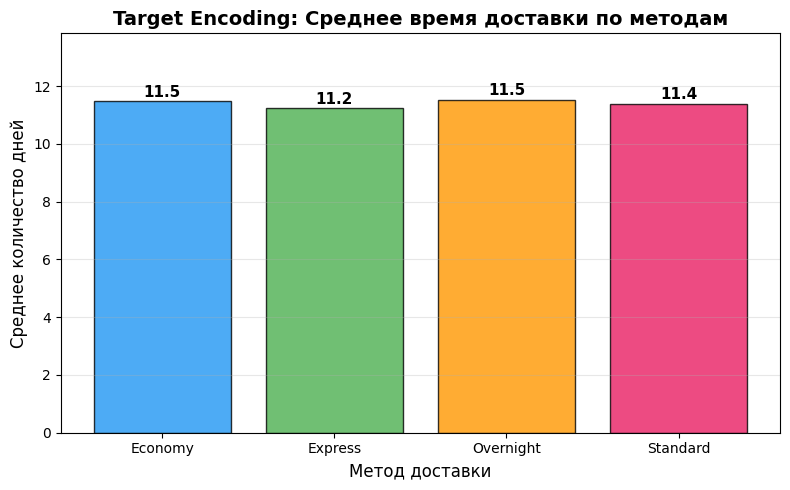

**Интерпретация:**

- Target Encoding заменяет категориальные значения на среднее значение целевой переменной
- Различия между методами доставки незначительны из-за синтетического характера данных

## Задача №22. Масштабирование по максимальному значению (MaxAbs Scaling)

Проведём масштабирование числового признака `Profit` (прибыль) методом MaxAbs Scaling.

```
Статистика признака 'Profit' до масштабирования:
count    7925.000000
mean       38.089692
std        48.895000
min      -100.730000
25%         6.770000
50%        24.190000
75%        60.190000
max       188.620000
Name: Profit, dtype: float64

Максимальное значение: 188.62
Минимальное значение: -100.73
```

```
Результат масштабирования (первые 10 строк):
```

|  | Profit | Profit_Scaled |
| --- | --- | --- |
| 1 | 5.56 | 0.029477 |
| 2 | 79.89 | 0.423550 |
| 4 | 60.13 | 0.318789 |
| 5 | 118.78 | 0.629732 |
| 6 | 19.49 | 0.103329 |
| 7 | -50.80 | -0.269325 |
| 8 | 4.75 | 0.025183 |
| 9 | -14.77 | -0.078306 |
| 10 | 66.85 | 0.354416 |
| 12 | -14.50 | -0.076874 |

```
Статистика признака 'Profit' после масштабирования:
count    7925.000000
mean        0.201939
std         0.259225
min        -0.534037
25%         0.035892
50%         0.128247
75%         0.319107
max         1.000000
Name: Profit_Scaled, dtype: float64

Максимальное значение после масштабирования: 1.000000
Минимальное значение после масштабирования: -0.534037
```

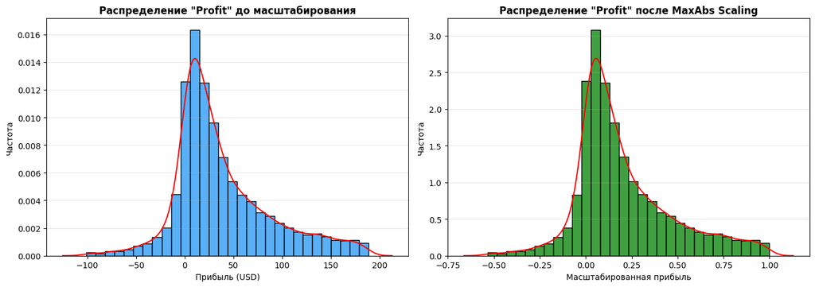

**Интерпретация:**

- MaxAbs Scaling делит каждое значение на максимальное абсолютное значение признака
- Максимальное значение после масштабирования равно 1.0
- Отрицательные значения прибыли (убытки) сохраняют знак после масштабирования